# TP1

Jérémie Perrin

11/03/2021

## Exercise 1

### Question 1.

#### Open a new script. Save your file as TP1.r.

### Question 2.

#### Create the vector (1, 2, 3, 4, 5).

```r
1:5
```

```
## [1] 1 2 3 4 5
```

### Question 3.

#### Assign the previous vector to X .

```r
X <- 1:5
```

### Question 4.

#### Check the contents of X.

```r
X
```

```
## [1] 1 2 3 4 5
```

### Question 5.

#### Create the vector Y with values (1, 4, 9, 16, 25).

```r
Y <- (1:5)**2;Y
```

```
## [1]  1  4  9 16 25
```

### Question 6.

#### Check that X and Y have the same length.

```r
length(X) == length(Y)
```

```
## [1] TRUE
```

### Question 7.

#### Plot the points defined by the two vectors X and Y by plot(X,Y).

Change the symbol: pch=2, then pch=3, etc. Change the type: type=“b”, then type=“l”. Change the color: col=“red”, then col=“blue”, etc. Add a title, add labels on both axes.

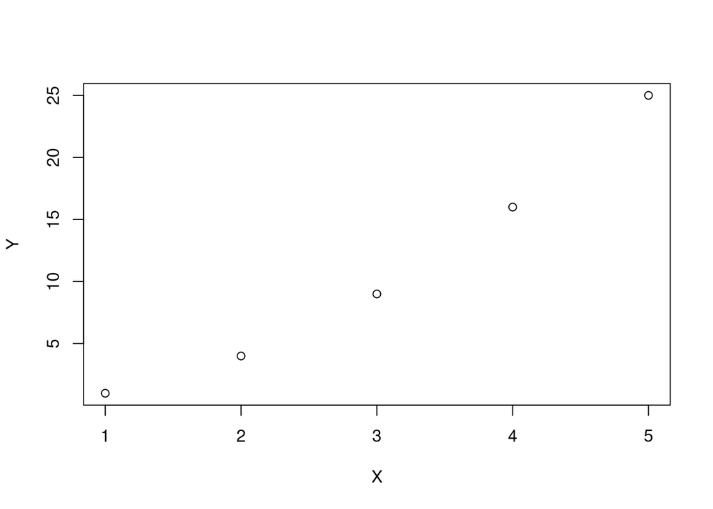

```r
plot(X,Y)
```

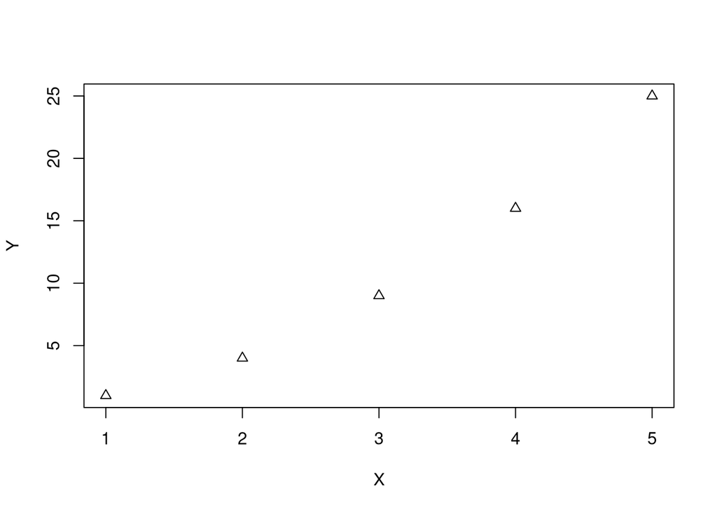

```r
plot(X,Y,pch=2)
```

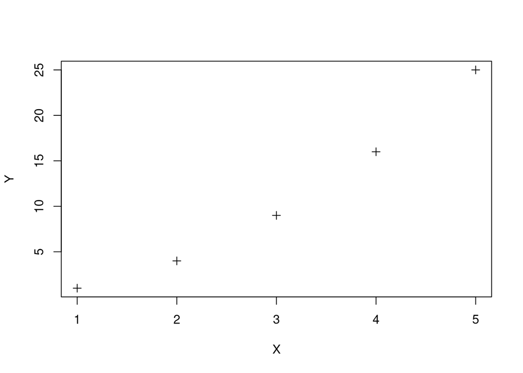

```r
plot(X,Y,pch=3)
```

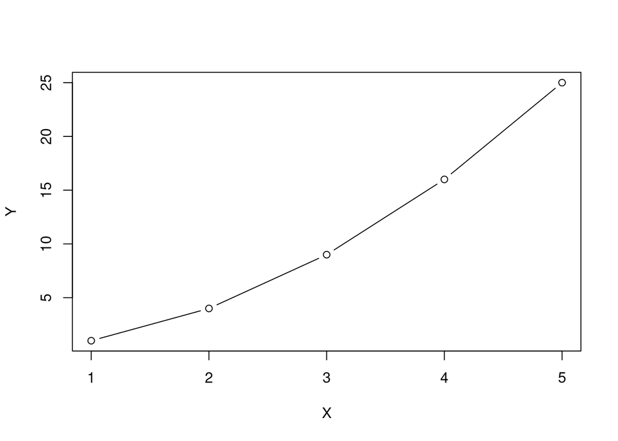

```r
plot(X,Y,type="b")
```

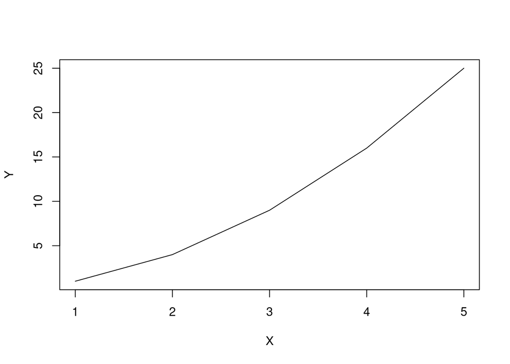

```r
plot(X,Y,type="l")
```

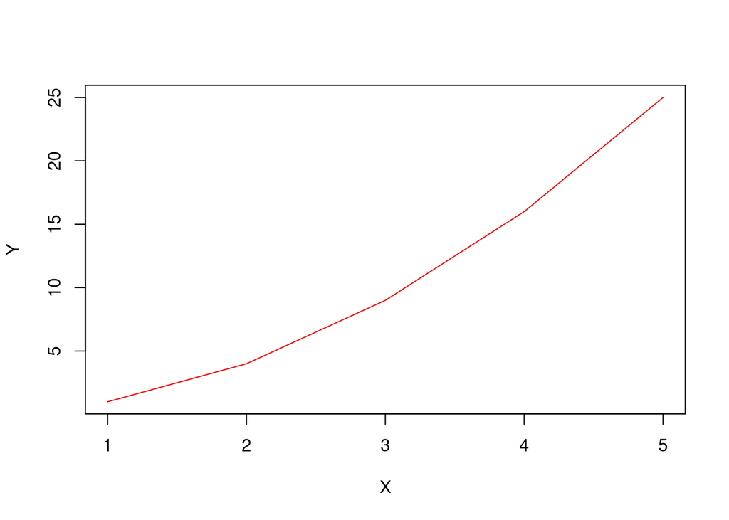

```r
plot(X,Y,type="l",col="red")
```

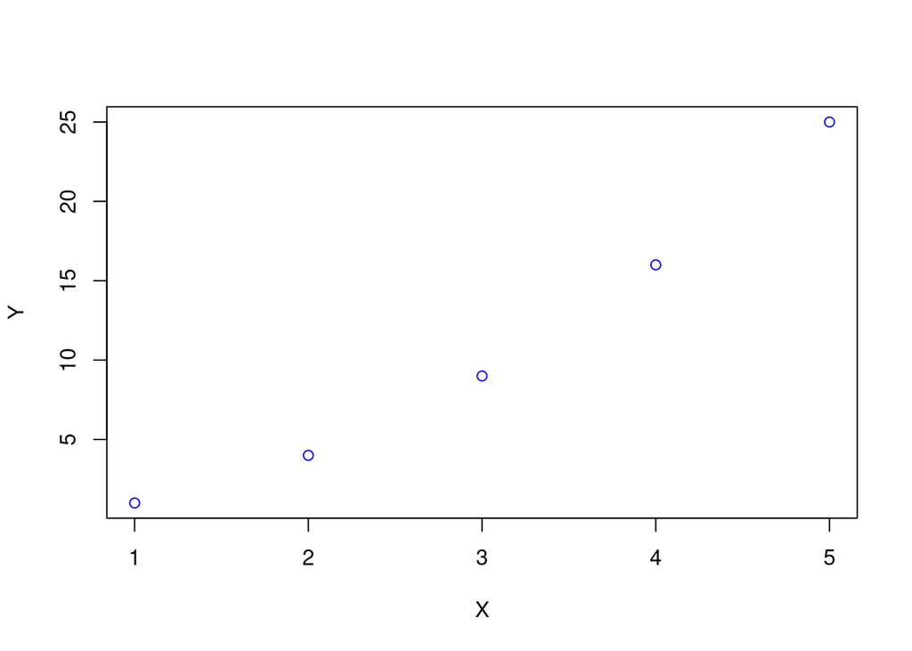

```r
plot(X,Y,col="blue")
```

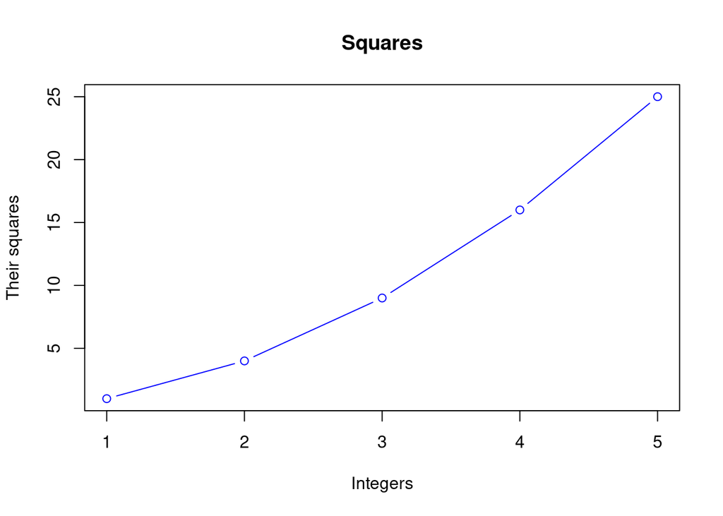

```r
plot(X,Y,type="b",col="blue", main="Squares", xlab="Integers",ylab="Their squares")
```

### Question 8.

#### Add the curve y = x² by curve(x^2,add=TRUE).

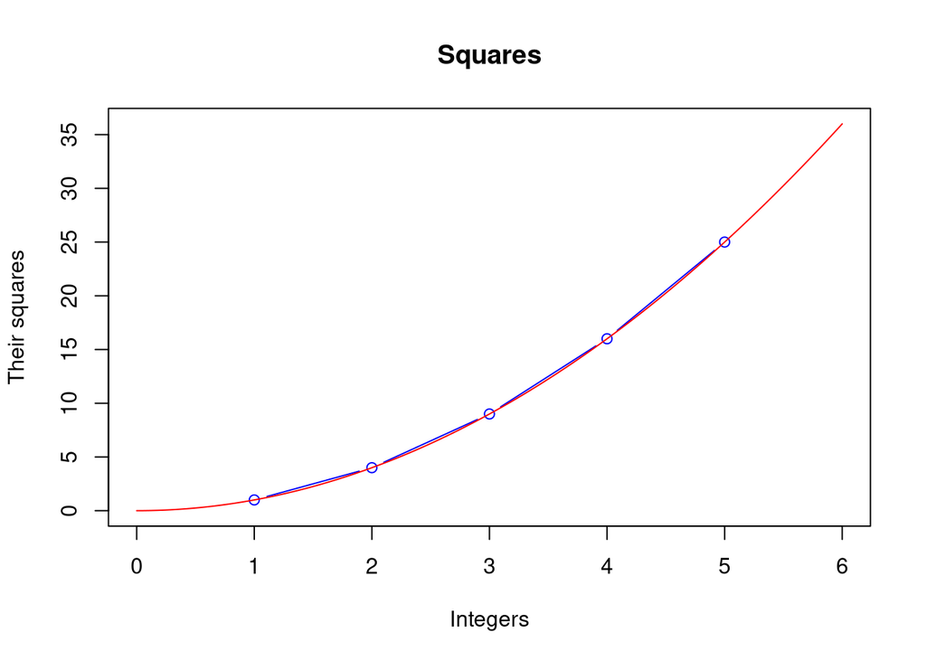

```r
plot(X,Y,type="b",xlim = c(0,6),ylim = c(0,36), col="blue", main="Squares", xlab="Integers",ylab="Their squares")
curve(x**2,add=TRUE,col="red")
```

### Question 9.

#### Create the vector X containing all integers from 0 to 7.

```r
X <- 0:7; X
```

```
## [1] 0 1 2 3 4 5 6 7
```

### Question 10.

#### Multiply X by 5, divide it by 5, add 5 to it.

```r
X <- ((5*X)/5) + 5; X
```

```
## [1]  5  6  7  8  9 10 11 12
```

### Question 11.

#### Compute the sum of X, its cumulative sums. sum(),cumsum(). Compute the square root of X, its third power. Sqrt()

```r
sum(X);
```

```
## [1] 68
```

```r
cumsum(X);
```

```
## [1]  5 11 18 26 35 45 56 68
```

```r
sqrt(X);
```

```
## [1] 2.236068 2.449490 2.645751 2.828427 3.000000 3.162278 3.316625 3.464102
```

```r
X**3
```

```
## [1]  125  216  343  512  729 1000 1331 1728
```

## Exercise 2

### Question 1.

#### Create the vector X containing (0, 1, 4, 9, 16).

```r
X <- (0:4)**2
```

### Question 2.

#### Extract from X the subvector with indices 3 and 5. Extract all values larger than 2. Extract all values larger than 2 and smaller than 10.

```r
X[c(3,5)];
```

```
## [1]  4 16
```

```r
X[X>2];
```

```
## [1]  4  9 16
```

```r
X[X>2 & X<10]
```

```
## [1] 4 9
```

### Question 3.

#### Create the vector Y containing 5 ones, the vector Z containing the sequence from 3 to 11 by step 2 (rep()seq().

```r
Y <- rep(1,5)
Z <- seq(from=3,to = 11, by = 2)
```

#### Concatenate X, Y, Z.

```r
c(X,Y,Z)
```

```
##  [1]  0  1  4  9 16  1  1  1  1  1  3  5  7  9 11
```

### Question 4.

#### Bind them as columns, and assign the result to XYZ.

```r
XYZ <- cbind(X,Y,Z);XYZ
```

```
##       X Y  Z
## [1,]  0 1  3
## [2,]  1 1  5
## [3,]  4 1  7
## [4,]  9 1  9
## [5,] 16 1 11
```

### Question 5.

#### Compute row sums and column sums of XYZ.

```r
colSums(XYZ);
```

```
##  X  Y  Z
## 30  5 35
```

```r
rowSums(XYZ)
```

```
## [1]  4  7 12 19 28
```

### Question 6.

#### Extract from XYZ:

1. row number 4

```r
XYZ[4,]
```

```
## X Y Z
## 9 1 9
```

2. column number 3

```r
XYZ[,3]
```

```
## [1]  3  5  7  9 11
```

3. rows with indices 3, 5, columns with indices 2, 3

```r
XYZ[c(3,5),c(2,3)]
```

```
##      Y  Z
## [1,] 1  7
## [2,] 1 11
```

4. rows such that X is larger than 2.

```r
XYZ[XYZ[,1]>2,]
```

```
##       X Y  Z
## [1,]  4 1  7
## [2,]  9 1  9
## [3,] 16 1 11
```

5. columns named “Y” and “Z”.

```r
XYZ[,c("Y","Z")]
```

```
##      Y  Z
## [1,] 1  3
## [2,] 1  5
## [3,] 1  7
## [4,] 1  9
## [5,] 1 11
```

## Exercise 3 : Etude de l’indice de masse corporelle

Un échantillon de dossiers d’enfants a été saisi. Ce sont des enfants vus lors d’une visite en première section de maternelle en 1996-1997, dans des écoles de Bordeaux. L’échantillon présenté ici est constitué de 10 enfants agés de 3 ou 4 ans.

Les données disponibles pour chaque enfant sont: • le sexe G ou F • le fait que leur école soit située en ZEP ou pas: O pour oui , N pour Non. • L’age en années et en mois à la date de la visite (deux variables, une pour le nombre d’années, une pour le nombre de mois). • Le poids en kilos arrondis à 100g prés. • La taille en cm arrondie à 0,5 cm prés

| Prénom | Erika | Celia | Eric | Eve | Paul | Jean | Adam | Louis | Jules | Léo | Type de Variable |
| --- | --- | --- | --- | --- | --- | --- | --- | --- | --- | --- | --- |
| Sexe | F | F | G | F | G | G | G | G | G | G | Qualitative |
| ZEP | O | O | O | O | N | O | N | O | O | O | Qualitative |
| Poids | 16 | 14 | 13,5 | 15,4 | 16,5 | 16 | 17 | 14,8 | 17 | 16,7 | Quantitative |
| An | 3 | 3 | 3 | 4 | 3 | 4 | 3 | 3 | 4 | 3 | Quantitative |
| Mois | 5 | 10 | 5 | 0 | 8 | 0 | 11 | 9 | 1 | 3 | Quantitative/Ordinale |
| Taille | 100 | 97,0 | 95,5 | 101.0 | 100,0 | 98,5 | 103 | 98 | 101,5 | 100.0 | Quantitative |

En statistiques, il est très important de connaître le type des variables étudiées: quantitatives, qualitatives, ordinales…Préciser ce qu’il en est dans le cas présent.

### Question 1.

#### Enregistrer les données de chacunes des variables ci-dessus dans des vecteurs que vous nommerez: Individus, Sexe, Zep, Taille, Poids.

```r
Individus <- c( 'Erika' , 'Celia' , 'Eric' , 'Eve' , 'Paul' , 'Jean' , 'Adam' , 'Louis' , 'Jules' , 'Léo' )
Sexe <- c('F','F','G','F','G','G','G','G','G','G')
Zep <- c(T, T,T,T,F,T,F,T,T,T)
Poids <- c( 16, 14 , 13.5 , 15.4 , 16.5, 16 , 17, 14.8 ,17 , 16.7)
Taille <- c(100,97.0,95.5,101.0,100.0,98.5,103,98,101.5,100.0)
```

### Question 2.

#### Calculer la moyenne des variables lorsque cela est possible.

```r
mean(Poids);
```

```
## [1] 15.69
```

```r
mean(Taille);
```

```
## [1] 99.45
```

```r
mean(Zep)
```

```
## [1] 0.8
```

### Question 3.

#### Utiliser la fonction summary() pour obtenir un résumé statistique des vecteurs que vous avez générés. Ce résumé dépend de la nature du vecteur. Observer.

```r
summary(Individus)
```

```
##    Length     Class      Mode
##        10 character character
```

```r
summary(Sexe)
```

```
##    Length     Class      Mode
##        10 character character
```

```r
summary(Taille)
```

```
##    Min. 1st Qu.  Median    Mean 3rd Qu.    Max.
##   95.50   98.12  100.00   99.45  100.75  103.00
```

```r
summary(Poids)
```

```
##    Min. 1st Qu.  Median    Mean 3rd Qu.    Max.
##   13.50   14.95   16.00   15.69   16.65   17.00
```

```r
summary(Zep)
```

```
##    Mode   FALSE    TRUE
## logical       2       8
```

### Question 4.

#### Calculer l’IMC des individus et regroupez les valeurs obtenues dans un vecteur que vous nommerez IMC (l’IMC est le quotient poids(en kg)/taille^2(en m)).

```r
IMC  <- Poids/(Taille/100)**2;IMC
```

```
##  [1] 16.00000 14.87937 14.80223 15.09656 16.50000 16.49102 16.02413 15.41025
##  [9] 16.50125 16.70000
```

### Question 5.

#### Regroupez ces variables dans la structure «tableau» de R: data.frame()

```r
data <- cbind.data.frame(Individus,Sexe,Zep,Poids,Taille,IMC);data
```

```
##    Individus Sexe   Zep Poids Taille      IMC
## 1      Erika    F  TRUE  16.0  100.0 16.00000
## 2      Celia    F  TRUE  14.0   97.0 14.87937
## 3       Eric    G  TRUE  13.5   95.5 14.80223
## 4        Eve    F  TRUE  15.4  101.0 15.09656
## 5       Paul    G FALSE  16.5  100.0 16.50000
## 6       Jean    G  TRUE  16.0   98.5 16.49102
## 7       Adam    G FALSE  17.0  103.0 16.02413
## 8      Louis    G  TRUE  14.8   98.0 15.41025
## 9      Jules    G  TRUE  17.0  101.5 16.50125
## 10       Léo    G  TRUE  16.7  100.0 16.70000
```

### Question 6.

#### Utilisez l’aide en ligne de R afin d’obtenir des informations sur la fonction plot().

```r
help(plot);
```

```
## Help on topic 'plot' was found in the following packages:
##
##   Package               Library
##   graphics              /usr/lib/R/library
##   base                  /usr/lib64/R/library
##
##
## Using the first match ...
```

```r
help(plot.default);
```

### Question 7.

#### Tracer le nuage de points du poids en fonction de la taille. Donner un titre à votre graphe, annotez les axes (paramètres de la fonction plot(), consultez la page d’aide

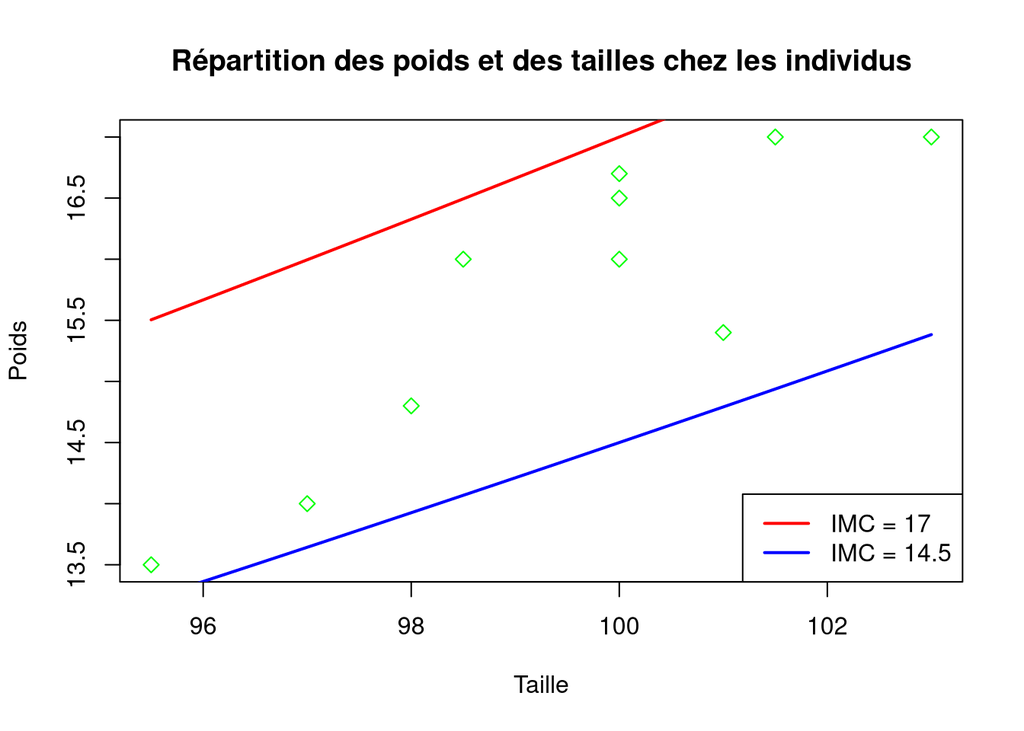

```r
plot(Taille,Poids,pch=5,col="green",xlab="Taille",ylab = "Poids",main="Répartition des poids et des tailles chez les individus")
curve(14.5*((x/100)**2),add=TRUE,col="blue",lw=2)
curve(17*((x/100)**2),add=TRUE,col="red",lw=2)
legend(x = "bottomright",          # Position
       legend = c("IMC = 17", "IMC = 14.5"),  # Legend texts
       lty = c(1, 1),           # Line types
       col = c("red", "blue"),           # Line colors
       lwd = 2)                 # Line width
```